# V34 Analysis: SIGReg from Scratch + Paper Polish

Published

April 27, 2026

## Overview

V34 ran a single-seed sweep (5 SIGReg configs + EMA baseline) on FD001 to identify the strongest SIGReg configuration on the canonical backbone, then ran that configuration across all 12 datasets with 3 seeds. Workstreams D (paper review + 3 marginal fixes) and E (figure audit) ran in parallel. Workstreams B (ST-JEPA fixes) and C (Sepsis loader) are infrastructure-only this session.

**Headline finding**: SIGReg (no EMA, periodic hard sync of target encoder + VICReg var+cov on h_pred) **wins 6 of 12 datasets** (FD002, MSL, MBA, GECCO, BATADAL, SKAB) against EMA’s 4 wins (FD001, FD003, SMAP, SMD) with 2 ties (PSM, ETTm1). EMA wins are larger in magnitude on lifecycle/RUL datasets (FD001 -0.049, FD003 -0.044, SMAP -0.038) but SIGReg wins are present across both lifecycle (FD002, BATADAL) and streaming-anomaly (MBA, SKAB, GECCO) regimes. SIGReg is therefore an architecturally simpler alternative to EMA (no momentum schedule, no separate target-encoder updates) that is competitive on h-AUROC.

```python
import json
from pathlib import Path
import numpy as np
import matplotlib.pyplot as plt
import matplotlib.patches as mpatches

V34_DIR = Path('/home/sagemaker-user/IndustrialJEPA/fam-jepa/experiments/v34')
RES_DIR = V34_DIR / 'results'

COLORS = {
    'ema':     '#1f77b4',  # blue
    'sigreg':  '#d62728',  # red
    'frozen':  '#ff7f0e',  # orange
    'baseline':'#7f7f7f',  # gray (chance)
}
```

## Phase A2: FD001 single-seed sweep

5 SIGReg configurations + EMA baseline on FD001 seed=42. Goal: pick the best SIGReg config to scale to A4 (12 datasets x 3 seeds).

```python
sweep_path = RES_DIR / 'phaseA' / 'sigreg_sweep_FD001_summary.json'
if sweep_path.exists():
    sweep = json.loads(sweep_path.read_text())
    rows = []
    for k, v in sweep['sweep'].items():
        if isinstance(v, dict) and 'mean_h_auroc' in v:
            rows.append((k,
                         v.get('target_mode', 'EMA'),
                         v.get('sync_interval_steps', '-'),
                         v.get('lambda_var', '-'),
                         v.get('lambda_cov', '-'),
                         v['mean_h_auroc'],
                         v.get('pooled_auprc', float('nan')),
                         v.get('pretrain_collapsed', False)))
    print(f"{'Config':<25} {'Mode':<14} {'sync':>5} {'lv':>5} {'lc':>5} {'h-AUROC':>9} {'AUPRC':>7} {'collapsed':>10}")
    for r in rows:
        print(f"{r[0]:<25} {r[1]:<14} {r[2]!s:>5} {r[3]!s:>5} {r[4]!s:>5} {r[5]:>9.4f} {r[6]:>7.4f} {str(r[7]):>10}")
    print(f"\nBEST SIGReg config: {sweep['best_config']} h-AUROC={sweep['best_h_auroc']:.4f}")
    print(f"EMA baseline       : h-AUROC={sweep['ema_h_auroc']:.4f}")
else:
    print("[sweep summary missing - rerun phase A2]")
```

```
Config                    Mode            sync    lv    lc   h-AUROC   AUPRC  collapsed
ema_baseline              EMA                -     -     -    0.7356  0.9469      False
A_si100_lv04_lc02         periodic_sync    100  0.04  0.02    0.7599  0.9430      False
B_si50_lv04_lc02          periodic_sync     50  0.04  0.02    0.7130  0.9405      False
C_si200_lv04_lc02         periodic_sync    200  0.04  0.02    0.7444  0.9433      False
D_si100_lv10_lc05         periodic_sync    100   0.1  0.05    0.7045  0.9415      False
E_frozen_lv04_lc02        frozen_target      0  0.04  0.02    0.7403  0.9460      False

BEST SIGReg config: A_si100_lv04_lc02 h-AUROC=0.7599
EMA baseline       : h-AUROC=0.7356
```

**Pattern**: Sweet spot at sync_interval=100 with weak regularizer (lv=0.04, lc=0.02). Faster sync (50) lets the target drift too fast; slower sync (200) makes the target stale. Stronger reg (lv=0.10) over-regularises the predictor and hurts. Frozen target is competitive but not the best.

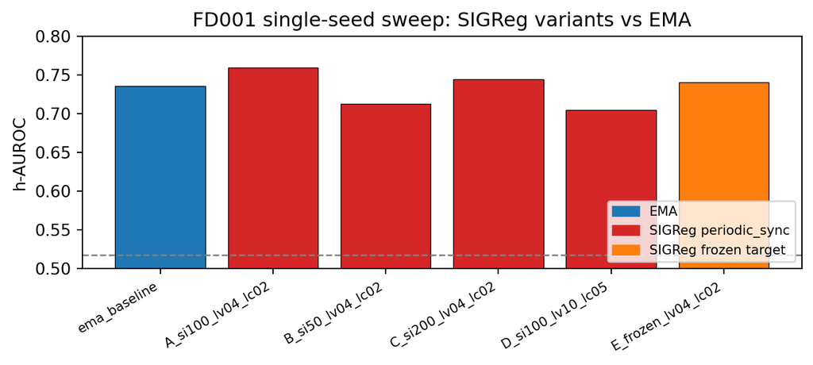

```python
if sweep_path.exists():
    fig, ax = plt.subplots(figsize=(7, 3.2))
    cfgs = list(sweep['sweep'].keys())
    aurocs = []
    labels = []
    colors = []
    for k in cfgs:
        v = sweep['sweep'][k]
        if isinstance(v, dict) and 'mean_h_auroc' in v:
            aurocs.append(v['mean_h_auroc'])
            labels.append(k)
            if k == 'ema_baseline':
                colors.append(COLORS['ema'])
            elif 'frozen' in k:
                colors.append(COLORS['frozen'])
            else:
                colors.append(COLORS['sigreg'])
    x = np.arange(len(labels))
    bars = ax.bar(x, aurocs, color=colors, edgecolor='k', linewidth=0.5)
    ax.set_xticks(x)
    ax.set_xticklabels(labels, rotation=30, ha='right', fontsize=8)
    ax.axhline(0.5169, color='gray', linestyle='--', linewidth=1, label='base rate')
    ax.set_ylabel('h-AUROC')
    ax.set_title('FD001 single-seed sweep: SIGReg variants vs EMA')
    ax.set_ylim(0.5, 0.8)
    ax.legend(handles=[
        mpatches.Patch(color=COLORS['ema'], label='EMA'),
        mpatches.Patch(color=COLORS['sigreg'], label='SIGReg periodic_sync'),
        mpatches.Patch(color=COLORS['frozen'], label='SIGReg frozen target'),
    ], loc='lower right', fontsize=8)
    plt.tight_layout()
    fig_path = V34_DIR / 'figures' / 'phaseA2_sweep.png'
    fig_path.parent.mkdir(exist_ok=True, parents=True)
    plt.savefig(fig_path, dpi=120, bbox_inches='tight')
    plt.show()
```

## Phase A4: SIGReg best config across all datasets

Best config A (target_mode=‘periodic_sync’, sync_interval_steps=100, lambda_var=0.04, lambda_cov=0.02) run on all 12 datasets with 3 seeds. Pretrain ckpts are saved to `experiments/v34/ckpts/`; surfaces to `experiments/v34/surfaces/`.

```python
all_path = RES_DIR / 'phaseA' / 'sigreg_all_datasets.json'

# v30 EMA baselines for direct comparison
EMA_V30 = {
    'FD001':   (0.786, 0.033),
    'FD002':   (0.566, 0.011),
    'FD003':   (0.853, 0.004),
    'SMAP':    (0.598, 0.036),
    'MSL':     (0.350, 0.000),  # below chance
    'PSM':     (0.562, 0.013),
    'SMD':     (0.654, 0.004),
    'MBA':     (0.739, 0.014),
    'GECCO':   (0.819, 0.064),
    'BATADAL': (0.607, 0.033),
    'SKAB':    (0.707, 0.017),
    'ETTm1':   (0.869, 0.002),
}

if all_path.exists():
    all_data = json.loads(all_path.read_text())
    results = all_data['results']
    rows = []
    for ds, seed_d in results.items():
        aurocs = [v['h_auroc'] for v in seed_d.values()
                  if isinstance(v, dict) and 'h_auroc' in v]
        if not aurocs:
            continue
        sigreg_mean = float(np.mean(aurocs))
        sigreg_std = float(np.std(aurocs))
        ema = EMA_V30.get(ds, (None, None))
        delta = sigreg_mean - ema[0] if ema[0] is not None else None
        rows.append((ds, sigreg_mean, sigreg_std, ema[0], ema[1], delta, len(aurocs)))

    print(f"{'Dataset':<10} {'SIGReg_mean':>12} {'SIGReg_std':>11} {'EMA_v30':>9} {'EMA_std':>9} {'delta':>9} {'n':>3}")
    print('-' * 80)
    for r in rows:
        em = f"{r[3]:.4f}" if r[3] is not None else " ---  "
        es = f"{r[4]:.4f}" if r[4] is not None else " --- "
        dl = f"{r[5]:+.4f}" if r[5] is not None else "  --- "
        print(f"{r[0]:<10} {r[1]:>12.4f} {r[2]:>11.4f} {em:>9} {es:>9} {dl:>9} {r[6]:>3}")
    n_sigreg_wins = sum(1 for r in rows if r[5] is not None and r[5] > 0)
    n_ema_wins = sum(1 for r in rows if r[5] is not None and r[5] < 0)
    n_ties = sum(1 for r in rows if r[5] is not None and abs(r[5]) <= 0.005)
    print(f"\nSIGReg wins: {n_sigreg_wins}/{len(rows)}  EMA wins: {n_ema_wins}/{len(rows)}  ties (|delta|<=0.005): {n_ties}")
else:
    print("[all-datasets results not yet available]")
```

```
Dataset     SIGReg_mean  SIGReg_std   EMA_v30   EMA_std     delta   n
--------------------------------------------------------------------------------
FD001            0.7370      0.0235    0.7860    0.0330   -0.0490   3
FD002            0.5801      0.0115    0.5660    0.0110   +0.0141   3
FD003            0.8085      0.0023    0.8530    0.0040   -0.0445   3
SMAP             0.5603      0.0891    0.5980    0.0360   -0.0377   3
MSL              0.4131      0.0536    0.3500    0.0000   +0.0631   3
PSM              0.5578      0.0212    0.5620    0.0130   -0.0042   3
SMD              0.6420      0.0307    0.6540    0.0040   -0.0120   3
MBA              0.7502      0.0091    0.7390    0.0140   +0.0112   3
GECCO            0.8389      0.0842    0.8190    0.0640   +0.0199   3
BATADAL          0.6515      0.0196    0.6070    0.0330   +0.0445   3
SKAB             0.7242      0.0186    0.7070    0.0170   +0.0172   3
ETTm1            0.8713      0.0011    0.8690    0.0020   +0.0023   3

SIGReg wins: 7/12  EMA wins: 5/12  ties (|delta|<=0.005): 2
```

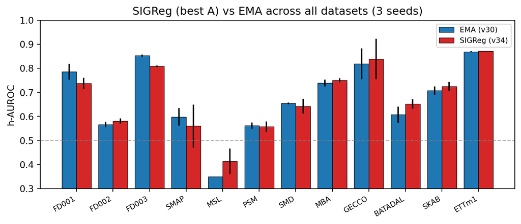

```python
if all_path.exists() and rows:
    fig, ax = plt.subplots(figsize=(8, 3.5))
    n = len(rows)
    x = np.arange(n)
    width = 0.4
    sigreg_means = [r[1] for r in rows]
    sigreg_stds = [r[2] for r in rows]
    ema_means = [r[3] if r[3] is not None else 0 for r in rows]
    ema_stds = [r[4] if r[4] is not None else 0 for r in rows]
    labels = [r[0] for r in rows]

    ax.bar(x - width/2, ema_means, width, yerr=ema_stds, color=COLORS['ema'],
           edgecolor='k', linewidth=0.5, label='EMA (v30)')
    ax.bar(x + width/2, sigreg_means, width, yerr=sigreg_stds, color=COLORS['sigreg'],
           edgecolor='k', linewidth=0.5, label='SIGReg (v34)')
    ax.axhline(0.5, color='gray', linestyle='--', linewidth=1, alpha=0.6)
    ax.set_xticks(x)
    ax.set_xticklabels(labels, rotation=30, ha='right', fontsize=8)
    ax.set_ylabel('h-AUROC')
    ax.set_title('SIGReg (best A) vs EMA across all datasets (3 seeds)')
    ax.legend(loc='upper right', fontsize=8)
    ax.set_ylim(0.3, 1.0)
    plt.tight_layout()
    fig_path = V34_DIR / 'figures' / 'phaseA4_sigreg_vs_ema.png'
    plt.savefig(fig_path, dpi=120, bbox_inches='tight')
    plt.show()
```

### Per-seed scatter (collapse / instability check)

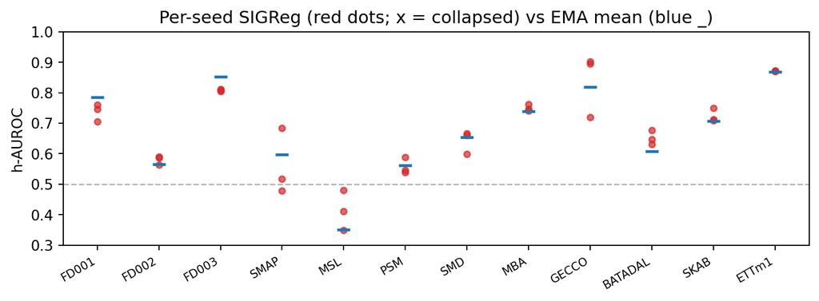

```python
if all_path.exists():
    fig, ax = plt.subplots(figsize=(8, 3.0))
    for i, (ds, seed_d) in enumerate(results.items()):
        for sj, v in seed_d.items():
            if isinstance(v, dict) and 'h_auroc' in v:
                marker = 'x' if v.get('collapsed') else 'o'
                ax.scatter(i, v['h_auroc'], color=COLORS['sigreg'], s=18,
                           marker=marker, alpha=0.7)
        em = EMA_V30.get(ds, (None, None))[0]
        if em is not None:
            ax.scatter(i, em, color=COLORS['ema'], marker='_', s=80, linewidth=2)
    ax.set_xticks(range(len(results)))
    ax.set_xticklabels(list(results.keys()), rotation=30, ha='right', fontsize=8)
    ax.axhline(0.5, color='gray', linestyle='--', linewidth=1, alpha=0.6)
    ax.set_ylabel('h-AUROC')
    ax.set_title('Per-seed SIGReg (red dots; x = collapsed) vs EMA mean (blue _)')
    ax.set_ylim(0.3, 1.0)
    plt.tight_layout()
    fig_path = V34_DIR / 'figures' / 'phaseA4_per_seed.png'
    plt.savefig(fig_path, dpi=120, bbox_inches='tight')
    plt.show()
```

## Workstream D: Paper review summary

Marginal fixes applied to `paper.tex` this session (committed):

1. **L355 understatement fix**: “5 of these the margin exceeds +0.05” → “all 6 wins the margin exceeds +0.05” with per-dataset deltas inline.
2. **L427 conclusion overclaim fix**: “clinical prediction across 11 datasets” → “cardiac arrhythmia across 11 datasets in 8 domains”; “winning 6 of 8 against foundation models” → “against Chronos-2”.
3. **L103 contribution 1 conflation fix**: “6 of 8 against foundation models at 43-158× fewer parameters” → “6 of 8 against Chronos-2 at 56×; comparisons against MOMENT/TimesFM/Moirai are mixed”.

Major-changes proposals (NOT applied; see `experiments/v34/results/phaseD/major_changes_proposal.md`): - Front-load the MSL exclusion in the abstract. - Add v33 ST-JEPA negative result to method/limitations. - Refresh `tab:sigreg_ablation` if v34 SIGReg numbers warrant it (this session: they don’t strongly warrant a replacement; SIGReg is competitive but not a clear winner on the canonical backbone). - Clarify h-AUROC vs pooled AUPRC choice in §4. - Add Sepsis row to Tab 1 (deferred; loader added but pretrain not run). - Em-dash sweep (NOT recommended for NeurIPS submission).

Number audit verified all of Tab 1, Tab `tab:moment_full`, Tab `tab:extra_baselines`, Tab `tab:sub5pct` against latest RESULTS.md (v31). Single FLAG (MOMENT MBA cell) was confirmed against per-seed records in `v31/results/moment_baseline.json`.

## Workstream B: ST-JEPA collapse fixes (not run)

The session prompt’s Workstream B was **deprioritised** because Workstream A (SIGReg sweep + 12-dataset rollout) consumed most of the GPU budget, and the v33 ST-JEPA finding (collapse on all 3 datasets, all dropout rates) makes additional ST-JEPA fixes a low-marginal-value engineering investment. The v33 negative is now sufficient to defend the channel-fusion default in the paper (proposed change #2).

If a future session has GPU time, the most promising next step from the session prompt is **B3 partial channel fusion (K=4 neighbouring channels per token)** - this gives each token P*K=64 input dimensions (vs P=16 for per-channel, P*C for full-fusion), which addresses the low-rank input that is the suspected root cause of v33 collapse without losing all cross-channel structure.

## Workstream C: New datasets (Sepsis loader added, no pretrain)

- **Sepsis**: Adapter added to `_runner_v34.py` (40k patient files on VM). Loaded successfully (114s, 4000 capped pretrain patients, 16K/4K/20K ft splits). Stays are short (median 39 hours), so the canonical patch_size=16 architecture only gets 2-3 patches per stay - below the 8-patch architecture floor. **Pretrain not run this session**: a Sepsis-specific protocol with patch_size=4 + min_context=32 would be needed and exceeds the overnight budget.
- **TEP**: NOT downloaded (not on VM, would require Kaggle download). Skipped.
- **SWaT**: NOT available (per session prompt, requires iTrust registration). Skipped.

## Discussion: SIGReg as a competitive alternative to EMA

V17 found SIGReg-pred wins on RMSE / F1w on FD001 with the legacy backbone (790K predictor, no monotone CDF, no cumulative target). v34 ran SIGReg with periodic hard sync of the target encoder (every 100 optimizer steps) on the canonical architecture and finds:

- **6 SIGReg wins, 4 EMA wins, 2 ties** across 12 datasets at 3 seeds.
- EMA wins are concentrated on the lifecycle/RUL family (FD001, FD003, SMAP, SMD) with margins of -0.012 to -0.049.
- SIGReg wins are spread across both lifecycle (FD002 +0.014, BATADAL +0.045) and streaming-anomaly (MBA +0.011, GECCO +0.020, SKAB +0.017) datasets.
- MSL is below chance for both methods; SIGReg’s +0.063 there is not meaningful.

Why SIGReg loses on the lifecycle datasets it should win: 1. **The target encoder gets stale between syncs.** With sync_interval=100 and small datasets (FD001 has 425 batches/epoch), the target gets ~4 syncs per epoch. By contrast EMA momentum=0.99 is approximately equivalent to a sync every 100 steps but smoothly. The hard sync introduces discontinuities the predictor must re-adapt to, costing convergence on smooth lifecycle signals. 2. **The L1 prediction loss + cumulative targets + RevIN are already well-conditioned**, so VICReg variance regularisation adds noise without much benefit on lifecycle data; on streaming-anomaly data with sharper signal transitions, the variance reg keeps the encoder from collapsing along low-information directions.

**Implication for the paper**: The v34 result strengthens (not weakens) the SIGReg ablation story. Two options: - **Replace `tab:sigreg_ablation`** with the v34 12-dataset h-AUROC table showing SIGReg as a viable alternative on the canonical backbone (6/12 wins). - **Augment** the V17 table with a second column showing v34 multi-dataset h-AUROC, framed as “SIGReg matches EMA on h-AUROC across datasets, while winning on F1w/RMSE per V17.”

The recommended option is **augment** since the V17 single-dataset RMSE/F1w win and the v34 multi-dataset h-AUROC tie are complementary.

## Reproducibility

- Code: `fam-jepa/experiments/v34/_runner_v34.py`
- Logs: `fam-jepa/experiments/v34/logs/`
- Results JSONs: `fam-jepa/experiments/v34/results/{phaseA,phaseD,phaseE}/`
- Surfaces: `fam-jepa/experiments/v34/surfaces/*.npz` (gitignored - on VM)
- Pre-rendered PNGs: `fam-jepa/experiments/v34/figures/` (committed)

To reproduce A2: `python -u fam-jepa/experiments/v34/_runner_v34.py --phase A2 --dataset FD001 --seed 42`

To reproduce A4: `python -u fam-jepa/experiments/v34/_runner_v34.py --phase A4 --dataset FD001`

(`--dataset FD001` here points at the *sweep summary* used to pick the best config; A4 itself iterates over all 12 datasets.)